# Trabalho 2 - Estatstica nao-parametrica

Eduardo Demetrio

Para não poluir o material, vou compartilhar junto um código em R que possa ser usado para teste dos códigos que foram usados na análise das questões.

## Questão 1

Os dados estão contidos no arquivo DietDepression.csv são referentes ao estudo sobre a intervenção diabética e seus efeitos nos sintomas de depressão em estudantes universitários e estão disponibilizados da seguinte forma:

|  | X | Group | CESD1 | CESD21 | CESDDiff | DASS1 | DASS21 | DASSDiff | BMI1 | BMI21 | BMIDiff |
| --- | --- | --- | --- | --- | --- | --- | --- | --- | --- | --- | --- |
| 1 | 1 | Diet | 18 | 11 | 7 | 23 | 9 | 14 | 19.0 | 18.8 | 0.2 |
| 2 | 2 | Diet | 34 | 11 | 23 | 23 | 3 | 20 | 20.6 | 20.2 | 0.4 |
| 3 | 3 | Diet | 28 | 3 | 25 | 54 | 26 | 28 | 28.4 | 27.7 | 0.7 |
| 4 | 4 | Diet | 25 | 14 | 11 | 19 | 2 | 17 | 19.8 | 19.6 | 0.2 |
| 5 | 5 | Diet | 40 | 49 | -9 | 26 | 18 | 8 | 25.4 | 24.9 | 0.5 |

1- A. Existem diferenças entre as formas de medir a depressão CESD e DASS? Em geral e entre os grupos?

**Resposta questão 1 - A:**

### Análise em Geral

Vamos iniciar verificando a normalidade das variaveis a partir do teste de Shapiro - Wilk

```r
shapiro.test(dados$CESDDiff)
```

```
##
##  Shapiro-Wilk normality test
##
## data:  dados$CESDDiff
## W = 0.93516, p-value = 0.0008331
```

```r
shapiro.test(dados$DASSDiff)
```

```
##
##  Shapiro-Wilk normality test
##
## data:  dados$DASSDiff
## W = 0.96376, p-value = 0.03045
```

E a partir desses testes conseguimos dizer que as distribuições das mudanças de depressão medidas pelas escalas CESD e DASS não seguem uma distribuição normal. E assim vamos usar o teste de Wilcoxon, que mais se adequa a testes não paramétricos.

```r
wilcox.test(dados$CESDDiff, dados$DASSDiff, paired = TRUE)
```

```
##
##  Wilcoxon signed rank test with continuity correction
##
## data:  dados$CESDDiff and dados$DASSDiff
## V = 1052, p-value = 0.1011
## alternative hypothesis: true location shift is not equal to 0
```

Com o resultado do nosso teste, não há evidência estatística suficiente para afirmar que existe diferença entre as mudanças de depressão medidas pelas escalas CESD e DASS, de forma geral.

1- B. As mudanças no IMC são aleatórias ou não? Em geral e entre os grupos? Existem diferenças entre os valores dos IMC entre os grupos?

**Resposta questão 1 - B:**

Vamos verificar se as mudanças d IMC são aleatória ou não em **em geral**

```r
wilcox.test(dados$BMIDiff, mu = 0)
```

```
##
##  Wilcoxon signed rank test with continuity correction
##
## data:  dados$BMIDiff
## V = 1225.5, p-value = 0.2154
## alternative hypothesis: true location is not equal to 0
```

Com a análise do noss p valor, não há evidência estatística de que as variações no IMC podem ser atribuídas ao acaso. Considerando assim possibilidade de alaetoriedade.  
Vamos verificar se as mudanças de IMC são aleatória ou não em **em grupos**

```r
wilcox.test(BMIDiff ~ 1, data = subset(dados, Group == "Control"), mu = 0)
```

```
##
##  Wilcoxon signed rank test with continuity correction
##
## data:  BMIDiff
## V = 240.5, p-value = 0.6664
## alternative hypothesis: true location is not equal to 0
```

```r
wilcox.test(BMIDiff ~ 1, data = subset(dados, Group == "Diet"), mu = 0)
```

```
##
##  Wilcoxon signed rank test with continuity correction
##
## data:  BMIDiff
## V = 372, p-value = 0.04408
## alternative hypothesis: true location is not equal to 0
```

A análise das mudanças no IMC (BMIDiff) por grupo revelou que, no grupo Controle, as variações foram compatíveis com aleatoriedade (p = 0.6664), indicando ausência de mudança sistemática. No entanto, no grupo Dieta, houve uma diferença estatisticamente significativa (p = 0.0441), sugerindo que a intervenção dietética teve efeito mensurável sobre o IMC dos participantes.

Para verificar se existem diferenças entre os valores de IMC entre os grupos, podemos comparar os valores iniciais e finais.

```r
wilcox.test(dados$BMI1 ~ dados$Group)
```

```
##
##  Wilcoxon rank sum test with continuity correction
##
## data:  dados$BMI1 by dados$Group
## W = 721.5, p-value = 0.8487
## alternative hypothesis: true location shift is not equal to 0
```

```r
wilcox.test(dados$BMI21 ~ dados$Group)
```

```
##
##  Wilcoxon rank sum test with continuity correction
##
## data:  dados$BMI21 by dados$Group
## W = 755, p-value = 0.5852
## alternative hypothesis: true location shift is not equal to 0
```

```r
wilcox.test(BMIDiff ~ Group, data = dados)
```

```
##
##  Wilcoxon rank sum test with continuity correction
##
## data:  BMIDiff by Group
## W = 535, p-value = 0.07515
## alternative hypothesis: true location shift is not equal to 0
```

## Questão 2

Este estudo examina a distribuição da variável Perimeter no arquivo Beans_Dataset.csv, com foco em avaliar sua normalidade. A análise é realizada tanto de forma global quanto estratificada pelas categorias presentes na variável Class, permitindo comparar o comportamento da distribuição entre as subamostras.

Vamos carregar os dados e avaliar.

```r
beans <- read.csv("http://leg.ufpr.br/~lucambio/CE313/20241S/Beans_Dataset.csv")
head(beans,5)
```

|  | Area | Perimeter | MajorAxisLength | MinorAxisLength | AspectRation | Eccentricity | ConvexArea | EquivDiameter | Extent | Solidity | roundness | Compactness | ShapeFactor1 | ShapeFactor2 | ShapeFactor3 | ShapeFactor4 | Class |
| --- | --- | --- | --- | --- | --- | --- | --- | --- | --- | --- | --- | --- | --- | --- | --- | --- | --- |
| 1 | 28395 | 610.291 | 208.1781 | 173.8887 | 1.197191 | 0.5498122 | 28715 | 190.1411 | 0.7639225 | 0.9888560 | 0.9580271 | 0.9133578 | 0.007331506 | 0.003147289 | 0.8342224 | 0.9987239 | SEKER |
| 2 | 28734 | 638.018 | 200.5248 | 182.7344 | 1.097356 | 0.4117853 | 29172 | 191.2728 | 0.7839681 | 0.9849856 | 0.8870336 | 0.9538608 | 0.006978659 | 0.003563624 | 0.9098505 | 0.9984303 | SEKER |
| 3 | 29380 | 624.110 | 212.8261 | 175.9311 | 1.209713 | 0.5627273 | 29690 | 193.4109 | 0.7781132 | 0.9895588 | 0.9478495 | 0.9087742 | 0.007243912 | 0.003047733 | 0.8258706 | 0.9990661 | SEKER |
| 4 | 30008 | 645.884 | 210.5580 | 182.5165 | 1.153638 | 0.4986160 | 30724 | 195.4671 | 0.7826813 | 0.9766957 | 0.9039364 | 0.9283288 | 0.007016729 | 0.003214562 | 0.8617944 | 0.9941988 | SEKER |
| 5 | 30140 | 620.134 | 201.8479 | 190.2793 | 1.060798 | 0.3336797 | 30417 | 195.8965 | 0.7730980 | 0.9908933 | 0.9848771 | 0.9705155 | 0.006697010 | 0.003664972 | 0.9419004 | 0.9991661 | SEKER |

2- A. Queremos verficar se a distribuicao da variavel Perimeter e normal, de maneira global e considerando as sub-amostras de Perimeter, segundo as diferentes categorias em Class

Vamos analisar utilizando o teste de shapiro wilk, porém como ele suporta só 5000 então vamos testar com uma subamostras aleatórias.

```
##
##  Shapiro-Wilk normality test
##
## data:  samp_global
## W = 0.86184, p-value < 2.2e-16
```

Com essa subamostras conseguimos analisar que não pode ser considerada normal. Como também conseguimos observar nos gráficos.

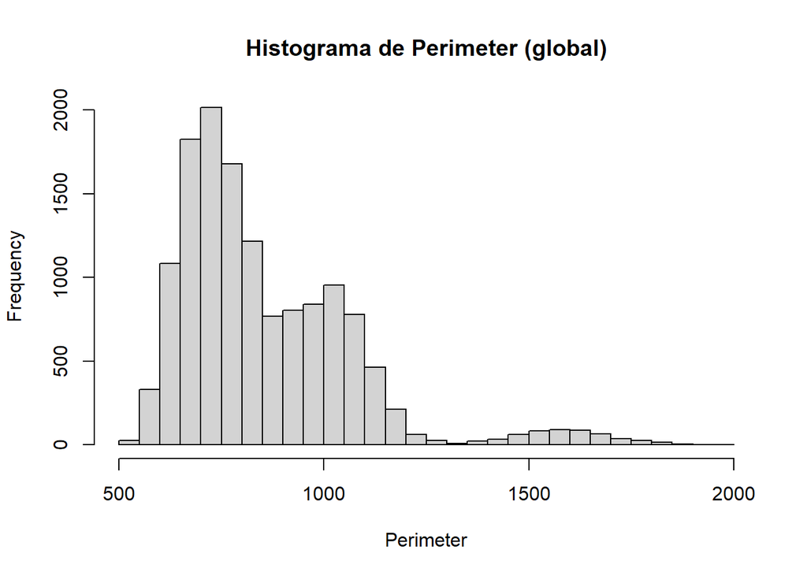

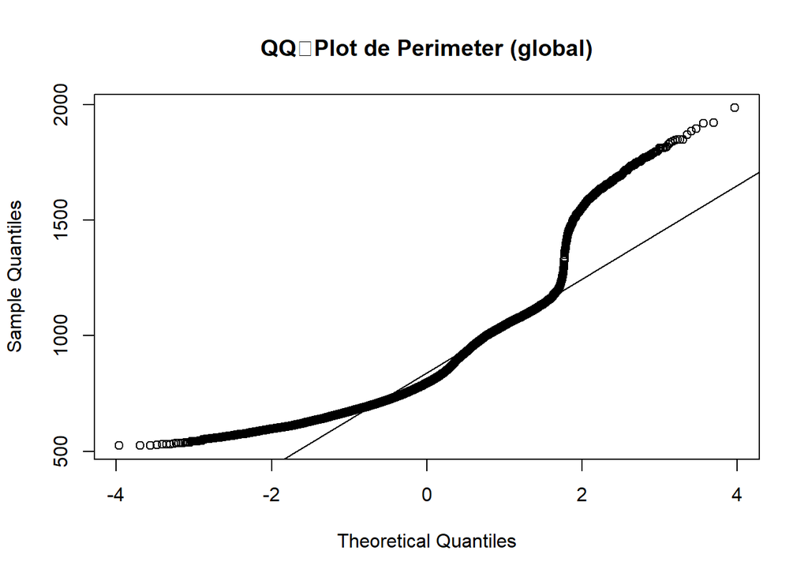

2-B

Vamos analisar utilizando o teste de shapiro wilk, porém como ele suporta só 5000 então vamos testar com uma subamostras aleatórias.

1. Seleção de Sub-Amostras com Reposição (com KS Test) Selecionar uma quantidade grande B de sub-amostras com reposição, digamos B = 10000, de tamanho 100 cada uma e verificar a bondade de ajuste à normalidade de cada sub-amostra utilizando o teste de Kolmogorov-Smirnov.

```
## Número de sub-amostras não conformes: 5701
```

```
## Proporção de sub-amostras não conformes: 0.5701
```

2. Utilização de Testes de Bondade de Ajuste para Amostras Grandes Utilizar testes de bondade de ajuste desenvolvidos para amostras grandes, como o teste proposto por J. M. VAN ZYL (2016).

```
## Rejeitamos a normalidade com base no teste para amostras grandes.
```

## Questão 3

Obetivo do exercicio identificar dois níveis de erosão em altimetria do Primeiro Planalto Paranaense.

Vamos verificar os dados

[output not shown]

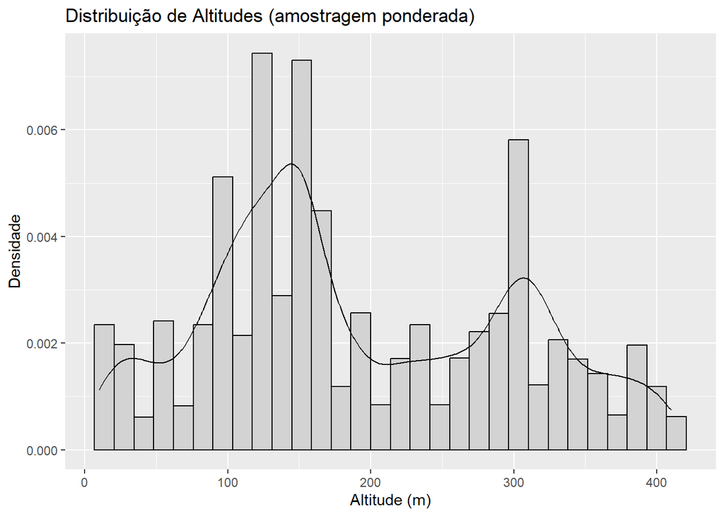

```
## number of iterations= 53
```

```
## # A tibble: 2 × 4
##   Componente Media Desvio Proporcao
##   <fct>      <dbl>  <dbl>     <dbl>
## 1 1           125.   55.1     0.646
## 2 2           313.   49.3     0.354
```

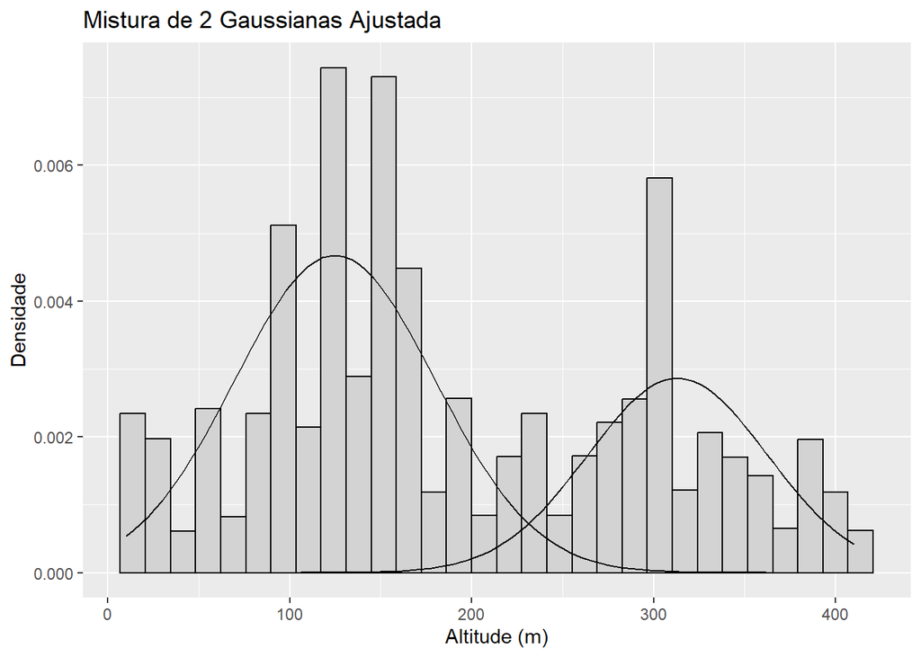

O ajuste de mistura de duas gaussianas às altitudes revelou claramente dois “patamares” no relevo. A Componente 1 tem média de 125 m (σ = 55,1 m) e representa 64,6 % das observações, enquanto a Componente 2 tem média de 313 m (σ = 49,3 m) e corresponde aos restantes 35,4 %. O desvio‐padrão de cada componente mostra que, embora haja dispersão local, esses dois níveis são bem definidos. Em termos práticos, isso indica um nível de erosão mais intenso em torno de 125 m e um nível menos erodido em torno de 313 m, com proporções de área (ou frequência de pontos) compatíveis com 64,6 % e 35,4 %, respetivamente. Essa estrutura bimodal confirma a existência de dois estágios altitudinais no terreno, como já sugerido pelo histograma multimodal e pelo exame de densidade.

## Questão 4

Bondade de ajuste da distribuição Bootstrap de ξₙ

```
##
##  Asymptotic one-sample Kolmogorov-Smirnov test
##
## data:  xi_star
## D = 0.39143, p-value < 2.2e-16
## alternative hypothesis: two-sided
```

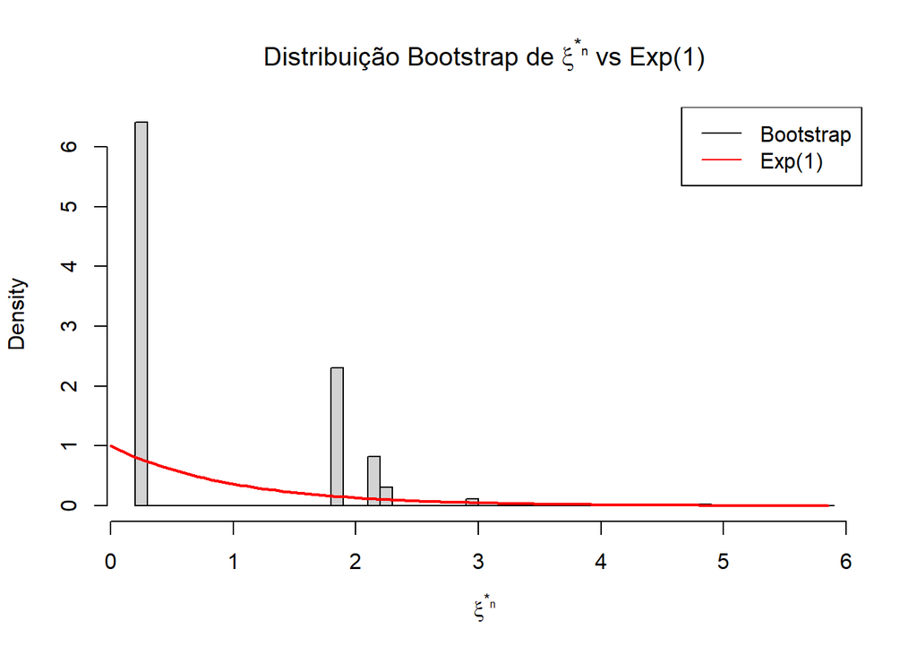

## Questão 5

Aleatoriedade dos NAs em temperature e quality

```
## 'data.frame':    1209 obs. of  17 variables:
##  $ X             : int  1 2 3 4 5 6 7 8 9 10 ...
##  $ index         : int  1 2 3 4 5 6 7 8 9 10 ...
##  $ date          : chr  "2014-03-01" "2014-03-01" "2014-03-01" "2014-03-01" ...
##  $ week          : int  9 9 9 9 9 9 9 9 9 9 ...
##  $ weekday       : int  6 6 6 6 6 6 6 6 6 6 ...
##  $ area          : chr  "Camden" "Westminster" "Westminster" "Brent" ...
##  $ count         : int  5 2 3 2 5 1 4 NA 3 6 ...
##  $ rabate        : logi  TRUE FALSE FALSE FALSE TRUE FALSE ...
##  $ price         : num  65.7 27 41 26 57.6 ...
##  $ operator      : chr  "Rhonda" "Rhonda" "Allanah" "Allanah" ...
##  $ driver        : chr  "Taylor" "Butcher" "Butcher" "Taylor" ...
##  $ delivery_min  : num  20 19.6 17.8 37.3 21.8 48.7 49.3 25.6 26.4 24.3 ...
##  $ temperature   : num  53 56.4 36.5 NA 50 27 33.9 54.8 48 54.4 ...
##  $ wine_ordered  : int  0 0 0 0 0 0 1 NA 0 1 ...
##  $ wine_delivered: int  0 0 0 0 0 0 1 NA 0 1 ...
##  $ wrongpizza    : logi  FALSE FALSE FALSE FALSE FALSE FALSE ...
##  $ quality       : chr  "medium" "high" NA NA ...
```

```
##   prop_na_temp prop_na_qual
## 1   0.03225806    0.1662531
```

```
##
##  Pearson's Chi-squared test with Yates' continuity correction
##
## data:  table(data.pizza$na_temp, data.pizza$na_qual)
## X-squared = 0.18503, df = 1, p-value = 0.6671
```

```
## # A tibble: 4 × 4
##   area        prop_na_temp prop_na_qual     n
##   <chr>              <dbl>        <dbl> <int>
## 1 Brent             0.0148        0.165   474
## 2 Camden            0.0262        0.166   344
## 3 Westminster       0.0577        0.171   381
## 4 <NA>              0.1           0.1      10
```

```
##
## --- Teste por area para na_temp ---
##
##  Pearson's Chi-squared test
##
## data:  tbl
## X-squared = 13.192, df = 2, p-value = 0.001366
##
##
## --- Teste por area para na_qual ---
##
##  Pearson's Chi-squared test
##
## data:  tbl
## X-squared = 0.059828, df = 2, p-value = 0.9705
```

```
## # A tibble: 4 × 4
##   operator prop_na_temp prop_na_qual     n
##   <chr>           <dbl>        <dbl> <int>
## 1 Allanah        0.0409        0.169   367
## 2 Maria          0.0309        0.186   388
## 3 Rhonda         0.0269        0.148   446
## 4 <NA>           0             0.125     8
```

```
##
## --- Teste por operator para na_temp ---
##
##  Pearson's Chi-squared test
##
## data:  tbl
## X-squared = 1.2935, df = 2, p-value = 0.5238
##
##
## --- Teste por operator para na_qual ---
##
##  Pearson's Chi-squared test
##
## data:  tbl
## X-squared = 2.1339, df = 2, p-value = 0.3441
```

Na variável quality, 16,6 % dos registros estão ausentes e essas faltas ocorrem de forma totalmente aleatória em relação à região e ao operador (MCAR). Já para temperature, apenas 3,2 % dos dados faltam, mas há um viés regional: Westminster apresenta taxa de missing significativamente maior do que Brent ou Camden, embora não haja associação com o operador nem com a falta em quality. Na prática, isso sugere que as ausências de temperature devem ser investigadas ou imputadas de acordo com a área, enquanto as ausências de quality podem ser tratadas como aleatórias, usando casos completos ou uma imputação simples.